# Graduation Rates in Higher Education and Financial Incentives

Jade Vasquez and Annaliz Arellano

2023-03-24

## Abstract

In this analysis, we build on prior literature, as well as findings from a dataset on the impact of economic factors, to address the ways in which academic success is influenced. Our research question specifically states: Do financial incentives have a relationship with whether a student drops out or graduates from college? Specifically, we will be determining the relationship between a student’s debt and their access to scholarships to compare its influence towards academic success. In this case, by financial incentives we are referring to a student’s access to scholarships and whether they have any debt and by comparing academic success we will be referring to whether they graduate college or drop out of college. Our existing dataset compiles data between the school years 2008/2009 to 2018/2019 between 4,424 undergraduates students from a Portuguese higher education institution. This data includes students enrolled in 17 different undergraduate degrees and includes information at the time of enrollment that is used to predict students academic success. Our analysis, in which we draw data from logistic regression models, is well-suited for our research focus and helps us better visualize the probability of both variables to determine a relationship. Our findings show that students who have financial debt are less likely to graduate from higher education. We also found that students who hold a scholarship are more likely to graduate from higher education.

## Introduction

Graduation rates in higher education have been a long standing concern. This is a complex issue that involves numerous variables that can be considered at fault. However, to try to understand the different variables that may influence a student’s academic success, we will be focusing on specific financial incentives, such as scholarship and debt. Financial incentives are designed to encourage students to persist in their studies and complete their higher education. The effectiveness of financial incentives may depend on a range of factors, but for the purpose of this study, we will only be looking at whether a student has access to a scholarship and whether they have any debt. In this case, data was gathered on a questionnaire basis where “1” means ‘yes’ they have a scholarship or they have debt and “0” means ‘no’ they do not hold a scholarship or they do not have debt. It is important to study the relationship between a student’s access to financial incentives, in terms of scholarship and debt, and their academic success to better understand if any disparities are affecting higher educational outcomes. Students come from different backgrounds and have different access to resources and we want to see if it plays a major role in influencing their success as students. Based on our variables, we hypothesize that: (1) Students who have access to a scholarship, will show higher graduation rates and lower dropout rates (2) Students who are inclined to have debt, will shower lower graduation rates and higher dropout rates.

## Literature Review

Prior literature on academic success, highly emphasized students socioeconomic background and its relationship to higher education. Although this is certainly useful, we will be focusing more on the article’s variables of social and cultural capital to help us make better connections to the access of financial incentives and the role it plays in higher education. MaryBeth Walpole’s article “Socioeconomic status and college: How SES affects college experience and outcomes” explores the relationship between socioeconomic status and college experiences and outcomes. Walpole identifies financial and academic barriers that low socioeconomic status students may face when attending college and how it impacts retention and graduation rates compared to students with a higher socioeconomic status. She states that, “family background, social and cultural capital, and habitus have a significant impact on educational aspirations, persistence, and attainment from the earliest schooling experiences, through high school, to college, and extending beyond college” (Walpole, 2003). This goes to show that one’s background and the access to resources one has, influences one’s educational attainment, whether that is a prestigious university or the simplicity of differentiating between graduation and dropping out. She argues that low income individuals, because of their upbringing, do not see education as an expectation, whereas high income students do and are expected to attend a four year college or prestigious university. This better helps us within our research because we are better able to build a comparison between one’s access to financial incentives and the correlation it has on students academic rates. Overall, this literature highlights the importance of considering SES in efforts to improve college access and success for all students.

The study in the literature can be improved by also exploring the experiences and outcomes of higher socioeconomic students. This article focuses, in depth, on the challenges and barriers faced by lower socioeconomic status students which can limit the literature’s ability to provide a comprehensive understanding of how SES affects academic success in comparison to those on opposite sides of the social spectrum. This article does not address the role of race or ethnicity in relation to SES and academic success, which we took into account while predicting our study and unfortunately, our results do not take this into consideration either. However, we were able to build off of the study in this literature by building a better comparison of the different resources one has access to and how these incentives play a factor in their success.

Prior literature by Zhang et al. in the article, “Family socioeconomic status and adolescents’ academic achievement: The moderating roles of subjective social mobility and attention” explores the relationship between family socioeconomic status and adolescents’ academic achievement. This piece of literature focuses on academic success, but heavily emphasizes the roles of subjective social mobility and attention and its influence towards educational achievement.The authors conducted a study using a sample of Chinese adolescents and found that higher family SES was positively associated with academic achievement. However, they also found that the relationship between family SES and academic achievement was moderated by subjective social mobility and attention. In this case, social mobility is referring to “an individual’s beliefs about his or her ability to attain a higher SES in the future” (Zhang et al., 2020). This is an important concept mentioned throughout the literature because it adds a new perspective towards academic success and educational attainment. This article is taking into consideration that those with greater academic success, such as higher graduation rates, are driven by motivation in terms of planning for their future. In this case, this can be applied to our methods of research by comparing those who have higher graduation rates because of access to scholarship versus those who dropout, meanwhile taking into consideration the motivation behind those specific actions and how the incentives may have been influential. Overall, this study highlights the importance of considering individual differences, such as subjective social mobility and attention, in understanding the relationship between family SES and academic achievement.

The study in the literature can be improved by extending the findings rather than confining to specific contexts. This study only focuses on a sample of Chinese adolescents, which may limit the generalizability of the findings to other cultural contexts. This study could be improved by exploring SES and the relationship to academic achievement in other societal contexts. We took this into account for our study and realized that we could have also included a dataset with various counties or one that proportionally showed a better disbursement of California. We were able to build off of this dataset by focusing on bigger factors of “socioeconomic status”, rather than individual factors such as one’s beliefs or attitudes towards academic success. In this case, we focused on comparing systemic factors such as access to scholarships and debt holders to find ways in which they correlate to disparities in academic achievement.

Other research that examines the relationship between socioeconomic status and individual academic achievement is a study done by Stephen J. Caldas and Carl Bankston III. looks at the relationship between a school’s socioeconomic status and academic success. This study examines students in high school in Louisiana. It controls for the SES of the individual, and measures academic success through “three 10th-grade components of the Louisiana Graduation Exit Examination”. The study found that “peer family social status in particular does have significant and substantive independent effects on individual academic achievement, only slightly less than an individual’s own family social status” (Caldas, S. J., & Bankston, 1997). This study may be improved because it does not take into account the school funding, only the socioeconomic status of peers. School funding may affect how many resources a student has while attending primary and secondary school, and affect their academic success. We can build our research off of this by looking at financial incentives as a predictor of academic success.

An article by Rodriguez-Hernandez, C. F., Cascallar, E., and Kyndt, E. also examined socio-economic status and academic performance in higher education (2020). This article measures socioeconomic status through “education, occupation, income, household resources, and neighborhood resources” and academic performance in higher education is measured through “achievement, competencies, and persistence”. The researchers found a “positive yet weak relationship between SES and academic performance in higher education. Prior academic achievement, university experience, and working status are more strongly related to academic performance than SES” (Rodriguez-Hernandez et al., 2020). In addition to examining the relationship between SES and academic performance, Rodriguez-Hernandez et al. (2020) also highlight the importance of considering other factors that may influence academic success. This suggests that a comprehensive understanding of the factors that contribute to academic success in higher education requires an examination of both individual and systemic factors. Furthermore, by analyzing their findings in their literature review, we can gain further insights into the different ways in which SES has been operationalized and measured in prior research. By building off of this study, we can further explore the relationship between SES and academic performance, while also considering other factors that may play a role in shaping academic outcomes.

## Data and Methods

We used a public dataset on Kaggle to do further analysis and answer our question. The dataset we used is named “Predict Students’ Dropout and Academic Success - Investigating the Social and Economic Factors” and it focuses on 4,424 students enrolled at higher institutions in Portugal (Realinho et al., 2022). The data was collected by the “National Competition Data” through the “Microsoft Access databases”. These students are enrolled in 17 different undergraduate degrees, and it was collected during the 2008-2009 and 2018-2019 school years (Realinho et al., 2022). This data includes variables of different financial incentives and academic performance to analyze possible predictors of student academic rates at the end of each semester. We chose this dataset because it best fits our research by focusing on a higher institution and comparing the different observations from its undergraduate students. The dataset has many different variables for each observation. For our research, we are going to look at the variables that include information about student’s access to financial incentives and their academic success to see if there is a relationship. The key variables are whether or not a student has debt, whether or not a student has a scholarship, and whether a student graduates or dropouts from the university. Analyzing this will allow us to see if financial incentives are associated with higher graduation rates.

We will be using a logistic regression analysis to see if there is a statistically significant relationship between financial incentives and academic success. But first, we wrangled the data and completed an exploratory data analysis to better understand our data. Our first step in the data wrangling was to make the ‘Target’ column binary, since we will only be evaluating students who either graduated or dropped out. This column originally had information on students who were currently enrolled at higher institutions, so we removed them from the dataset to make this variable binary. Next, we created visualizations and tables to display our data. We found that for our target variable, 1421 students dropped while 2209 students graduated. Out of all of our observations 2661 students do not hold a scholarship, while 969 students do. Lastly, 3217 students do not have debt, while 413 students do.

## Analysis

We used RStudio and R programming language to complete our data analysis. We implemented two logistic regression models to determine if students are more likely to graduate college based on financial incentives. We are using logistic regression because our target variable (dropout or graduate) is binary. Our first model aims to find the probability that a student graduated college based on whether or not they hold debt. This was the output of our first model:

```
## # A tibble: 2 × 5
##   term            estimate std.error statistic  p.value
##   <chr>              <dbl>     <dbl>     <dbl>    <dbl>
## 1 (Intercept)        0.642    0.0371      17.3 3.68e-67
## 2 factor(Debtor)1   -1.77     0.120      -14.7 5.61e-49
```

We have interpreted this as showing that there is a -1.77 coefficient when ‘Debtor’ is true, meaning that there is negative gain in graduation rate when a student has debt. In other words, a student is less likely to graduate if they have debt. By looking at the p-value, we can see that this is statistically significant. The p-value is 5.6e^-49, which is less than 0.05. We also created a barplot to visualize the data.

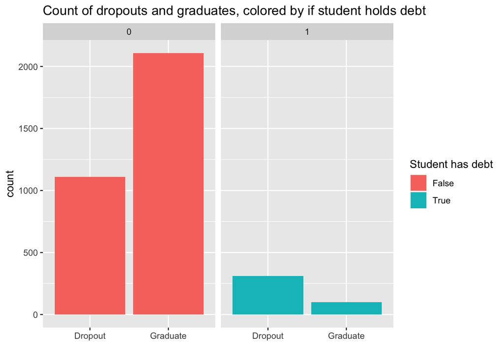

The correlation coefficient and visualization confirm the relationship between graduation rate and whether or not a student has debt.

Our second logistic regression model aims to analyze the relationship between a student graduating college and whether or not they hold a scholarship. Below are the results of our analysis:

```
## # A tibble: 2 × 5
##   term                          estimate std.error statistic  p.value
##   <chr>                            <dbl>     <dbl>     <dbl>    <dbl>
## 1 (Intercept)                     0.0654    0.0388      1.69 9.17e- 2
## 2 factor(`Scholarship holder`)1   1.76      0.101      17.5  1.49e-68
```

From this table, we can see that there is a 1.76 coefficient when a student has a scholarship. This positive coefficient means that there is an increase in graduation rate when a student has a scholarship, in other words, a student is more likely to graduate when they hold a scholarship. By looking at the p-value, we see that this relationship is statistically significant, since the p-value is less than 0.05. To continue this analysis, we created a visualization for this model.

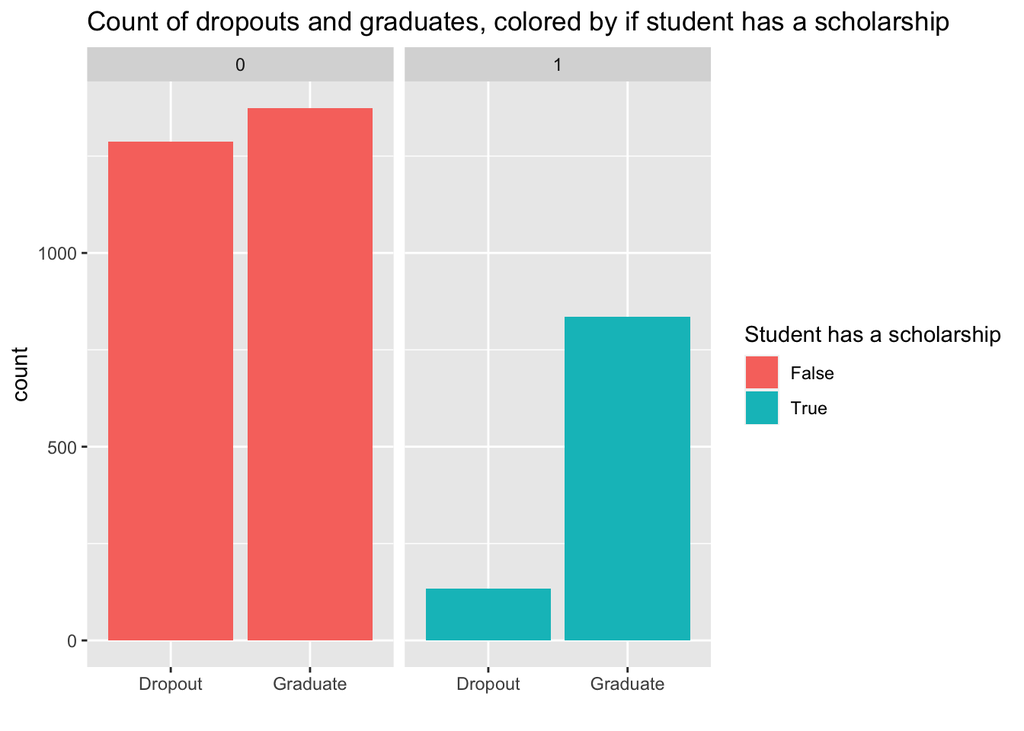

This barplot as well as the coefficient confirm our analysis that students are more likely to graduate when they have a scholarship.

## Discussion

In our study, we found that students who hold scholarships are more likely to graduate from college, while those with debt are less likely to do so. These findings align with prior research that has identified financial incentives as an important factor in predicting academic success (Walpole, 2003). In particular, our findings support Walpole’s argument that low-income students may face financial barriers that limit their access to higher education, while high-income students may have greater access to financial resources that support their academic success. Although, students who hold scholarships may have other advantages, such as higher academic ability or more support from family, and so there may be other reasons contributing to their success that were not accounted for through our analysis. Our results matter because everyone comes from a different background, and we want to see if disparities in socioeconomic status, or financial incentives, affect success in higher education.

However, our findings also extend prior research by specifically examining the role of scholarships and debt in predicting graduation rates. This is an important contribution, as it provides more targeted insights into the specific financial incentives that may be most effective in supporting students’ academic success. Furthermore, our study adds to the existing literature by providing evidence from a different context - that of Portuguese undergraduate students - which may have different social and economic factors that impact students’ access to financial incentives and academic success.

There were several limitations to our study; the first is that our analysis was done on a dataset of Portuguese students. If we want to generalize our analysis to higher education in the United States, then we would want to re-run this analysis with data from the U.S. A second limitation is that our analysis did not interpret different racial backgrounds or gender identities. These could be confounding variables that affected our analysis. A limitation is also that by using a logistic regression, we assume that the relationship between the predictor variables and outcome variables are linear, which may not always be the case. Further research on this topic may include conducting another analysis with data from students in the higher education system in the United States. Another avenue would be to include variables such as racial background and gender identity.

## Conclusion

Our study aimed to examine the relationship between financial incentives and academic success among undergraduate students in Portugal. Through logistic regression analysis, we found that students who hold scholarships are more likely to graduate from college, while those with debt are less likely to do so. Our findings support prior research that has identified financial incentives as an important factor in predicting academic success, and extend the literature by specifically examining the role of scholarships and debt in predicting graduation rates.

While our study provides valuable insights, there are limitations that need to be addressed in future research. These include the need to consider different cultural contexts and the potential confounding variables such as race and gender. Overall, our study contributes to the ongoing discussion on the importance of financial incentives in supporting students’ academic success and provides important implications for policymakers and higher education institutions to consider when designing and implementing financial aid programs.

## Bibliography

Caldas, S. J., & Bankston, C. (1997). Effect of school population socioeconomic status on individual academic achievement. The Journal of Educational Research, 90(5), 269-277.

Realinho, V., Machado, J., Baptista, L., & Martins, M. V. (2022). Predicting Student Dropout and Academic Success. Data, 7(11), 146. MDPI AG.

Rodriguez-Hernandez, C. F., Cascallar, E., & Kyndt, E. (2020). Socio-economic status and academic performance in higher education: A systematic review. Educational Research Review, 29, 100305.

Walpole, M. (2003). “Socioeconomic status and college: How SES affects college experiences and outcomes.” The review of higher education, 27(1), 45-73.

Zhang, F., Jiang, Y., Hua, M., Yang, C., & Silin, H. (2020). “Family socioeconomic status and adolescents’ academic achievement: The moderating roles of subjective social mobility and attention.” Journal of Youth and Adolescence, 49(9), 1821-1834. doi:https://doi.org/10.1007/s10964-020-01287-x